# MDS votaciones

yo

3 de marzo de 2017

## Datos

De la base de votaciones de senadores y partidos tenemos:

```r
senado_votaciones <- readRDS("/home/mb45296/votacionEspacialMexico/source_rds/L63_A2_N1_PO1_RESULTS.RDS")

part<-readRDS('/home/mb45296/votacionEspacialMexico/source_rds/L63_A2_N1_PO1_ASISTENCIA_ASISTENCIA.RDS')
```

## Missings

revisamos la cantidad de datos missing:

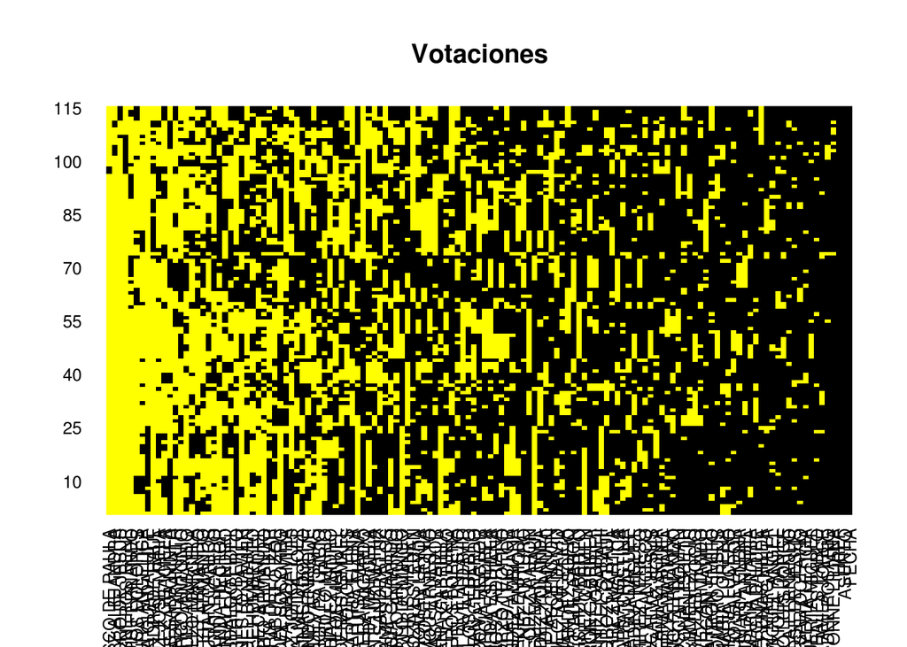

```r
library(Amelia)
missmap(senado_votaciones, main="Votaciones",
        col=c("yellow", "black"), legend=FALSE)
```

```r
datana<-is.na(senado_votaciones)
senado_votaciones[datana]<-0
```

## Variables

Eliminamos variables que no analizaremos:

```r
senadores_votaciones<-senado_votaciones[,-3:-1]
```

## Centrado y escalamiento de Datos

```r
X <- as.matrix(senadores_votaciones)
X <- scale(X, center = TRUE, scale = TRUE)
X[1,1:2]
```

```
##      ACOSTA ISLAS ANABEL ALBARRAN MENDOZA ESTEBAN
##                0.4146818               -1.2647548
```

## Distancias

Obtenemos la matriz de distancias entre individuos:
$$D =
\begin{pmatrix}
d_{1,1} & d_{1,2} & \cdots & d_{1,n} \\
d_{2,1} & d_{2,2} & \cdots & d_{2,n} \\
\vdots & \vdots & \ddots & \vdots \\
d_{n,1} & d_{n,2} & \cdots & d_{n,n}
\end{pmatrix}$$
que en este caso n=132.

```r
D <- as.matrix(dist(t(X)))
```

posteriormente convertimos la matriz de distancias al cuadrado:
$$D2_{i,j}=d_{i,j}^2 \ para\ toda\ i,j$$

```r
D2 <- D ^2
D2[1:2,1:2]
```

```
##                          ACOSTA ISLAS ANABEL ALBARRAN MENDOZA ESTEBAN
## ACOSTA ISLAS ANABEL                   0.0000                 291.2624
## ALBARRAN MENDOZA ESTEBAN            291.2624                   0.0000
```

## matriz centradora de datos

Utilizamos de la mtriz centradoradora para las distancias al cuadrado:
$$C=I-\frac{1}{n}\mathbf{1}\textbf{1}^\intercal$$

```r
n <- nrow(D2)
ones <- rep(1, n)
C <- diag(1, n) - (1 / n) * ones %*% t(ones)
C[1:3,1:3]
```

```
##              [,1]         [,2]         [,3]
## [1,]  0.992424242 -0.007575758 -0.007575758
## [2,] -0.007575758  0.992424242 -0.007575758
## [3,] -0.007575758 -0.007575758  0.992424242
```

## matriz doble centradora

Utilizamos de la matriz doble centradora:
$$B=-\frac{1}{2}CD_{2}C$$

```r
B <- - (1 / 2)*C %*% D2 %*% C
B[1:3,1:3]
```

```
##           [,1]     [,2]      [,3]
## [1,] 111.93081 -31.0145 -20.18973
## [2,] -31.01450 117.3026 -26.52440
## [3,] -20.18973 -26.5244 109.46238
```

## Descomposición espectral

Por el teorma visto en clase sabemos que si B es una matriz semidefinida positiva:
$$B=UG_{2}{U}^\intercal=X{X}^\intercal\\
con\ X=UG_{2}^{\frac{1}{2}}$$

```r
## eigen vectores de B
eigen_decomposition <- eigen(B)
## eigenvectores
U <- eigen_decomposition$vectors
U[1:3,1:3]
```

```
##             [,1]        [,2]        [,3]
## [1,] -0.08100343  0.15122977 -0.07757829
## [2,]  0.14220605  0.03399014  0.17372932
## [3,] -0.08269415 -0.15264190  0.01451902
```

```r
## eigenvalores
G2 <- diag(eigen_decomposition$values)
G2[1:3,1:3]
```

```
##          [,1]     [,2]     [,3]
## [1,] 1281.724    0.000   0.0000
## [2,]    0.000 1115.179   0.0000
## [3,]    0.000    0.000 847.5205
```

```r
## Xstar se compone de eigenvalos y eigenvectores de B
Xstar <- U %*% (G2 ^ (0.5))
Xstar[1:3,1:3]
```

```
##           [,1]      [,2]       [,3]
## [1,] -2.900018  5.050212 -2.2584750
## [2,]  5.091143  1.135077  5.0576437
## [3,] -2.960547 -5.097369  0.4226806
```

## reducción de dimensiones

obtendremos las coordenadas de cada uno de los senadores con respecto a las primeras 2 dimensiones:
$$X_{k}=U^{[1:k]}(G_{2}^{\frac{1}{2}})_{[1:k]}^{[1:k]}$$

```r
## reducción de dimensiones
k <- 2

Xk <- U[, 1:k] %*% (G2 ^ 0.5)[1:k, 1:k]
Xk[1:5,]
```

```
##            [,1]      [,2]
## [1,] -2.9000177  5.050212
## [2,]  5.0911429  1.135077
## [3,] -2.9605472 -5.097369
## [4,] -6.4819404 -1.412497
## [5,]  0.9208002 -1.006442
```

## gráfica de datos

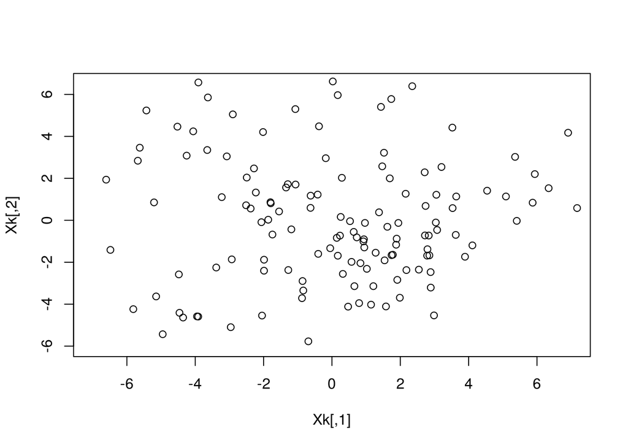

```r
plot(Xk, xlim = c(-7, 7), ylim = c(-6, 6.5))
```

## función alterna

esta es una función de R que genera el mismo proceso que hicimos manualmente, a apartir de la matriz D de distancias:

```r
## alternative:
cmds <- cmdscale(D)
cmds
```

```
##                                                 [,1]        [,2]
## ACOSTA ISLAS ANABEL                      -2.90001775  5.05021194
## ALBARRAN MENDOZA ESTEBAN                  5.09114292  1.13507694
## ALBORES GLEASON ROBERTO ARMANDO          -2.96054724 -5.09736906
## ALCALA RUIZ BLANCA MARIA DEL SOCORRO     -6.48194044 -1.41249711
## ALVAREZ GARCIA IVONNE LILIANA             0.92080021 -1.00644162
## AMADOR GAXIOLA DANIEL                     0.14183116 -0.83857747
## ARAUJO LARA ANGELICA DEL ROSARIO          1.78138425 -1.64257218
## ARECHIGA AVILA JORGE                      0.94643362 -1.29510686
## AVILA RUIZ DANIEL GABRIEL                -2.49260277  2.03781070
## AYALA ALMEIDA JOEL                        2.98624828 -4.53553396
## BARBOSA HUERTA MIGUEL                     2.54299497 -2.35320152
## BARRERA TAPIA MARIA ELENA                -2.28144542  2.47233522
## BARROSO AGRAMONT RICARDO                  1.58036653 -4.10855292
## BARTLETT DIAZ MANUEL                     -3.90814057  6.57222814
## BERISTAIN NAVARRETE LUZ MARIA             3.53024563  0.58062727
## BLASQUEZ SALINAS MARCO ANTONIO           -0.40165833 -1.60060877
## BURGOS GARCIA ENRIQUE                     0.63724763 -0.55477882
## BURQUEZ VALENZUELA FRANCISCO DE PAULA    -0.62646809  0.59162723
## CALDERON HINOJOSA LUISA MARIA            -4.47950138 -2.58116826
## CARDENAS FONSECA MANUEL                  -2.93130086 -1.86366902
## CASILLAS ROMERO JESUS                     4.10967912 -1.19632249
## CAVAZOS LERMA MANUEL                      0.17128245 -1.68912566
## CEBALLOS LLERENAS HILDA                   1.62130707 -0.31036303
## CERVANTES ANDRADE RAUL                   -3.91244747 -4.59143859
## CHICO HERRERA MIGUEL ANGEL                2.72148124 -0.72272859
## CORDERO ARROYO ERNESTO JAVIER            -3.38532579 -2.25256456
## COTA JIMENEZ MANUEL HUMBERTO             -1.98669220 -1.88038531
## CUELLAR CISNEROS LORENA                   0.31925712 -2.55671932
## CUEVAS BARRON GABRIELA                    0.16979522  5.96813683
## DAVILA FERNANDEZ ADRIANA                 -5.14400560 -3.63118207
## DE LA PENA GOMEZ ANGELICA                 0.83417495 -2.04338351
## DE LA TORRE VALDEZ YOLANDA                0.57351151 -1.98253748
## DELGADO CARRILLO MARIO                   -5.62286344  3.46027728
## DEMEDICIS HIDALGO FIDEL                   0.47304407 -4.11844238
## DIAZ LIZAMA ROSA ADRIANA                  2.71391403  2.28716812
## DIAZ SALAZAR MARIA CRISTINA               1.27886318 -1.54663364
## DOMINGUEZ ARVIZU MARIA HILARIA            1.74538905 -1.66129820
## DORANTES MARTINEZ CARMEN                 -4.95158810 -5.43287040
## ENCINAS RODRIGUEZ ALEJANDRO DE JESUS     -2.06376583 -0.09108721
```

[output cut: 78 more lines]

```
## SANCHEZ GARCIA GERARDO                   -2.04573219 -4.54345006
## SANCHEZ JIMENEZ LUIS                      1.37736057  0.38067936
## SANSORES SAN ROMAN LAYDA                 -5.42917438  5.23640710
## SANTANA GARCIA JOSE DE JESUS             -1.06467078  1.70477775
## TAGLE MARTINEZ MARTHA ANGELICA           -5.20566923  0.85314897
## TOLEDO LUIS JORGE                         1.87822520 -1.16579726
## TORRES CORZO TEOFILO                     -0.41773385  1.22500186
## TORRES GRACIANO FERNANDO                 -1.34250821  1.56325622
## TORRES PEIMBERT MARIA MARCELA            -4.25104087  3.08211470
## URZUA RIVERA RICARDO                      5.93600614  2.20207417
## VEGA CASILLAS SALVADOR                    5.35878312  3.02278873
## YUNES LANDA HECTOR                       -4.35533560 -4.63730486
## YUNES MARQUEZ FERNANDO                    2.85163833 -1.67229180
## YUNES ZORRILLA JOSE FRANCISCO            -1.27686469 -2.37240829
## ZAMORA JIMENEZ ARTURO                     1.43438129  5.40568363
```

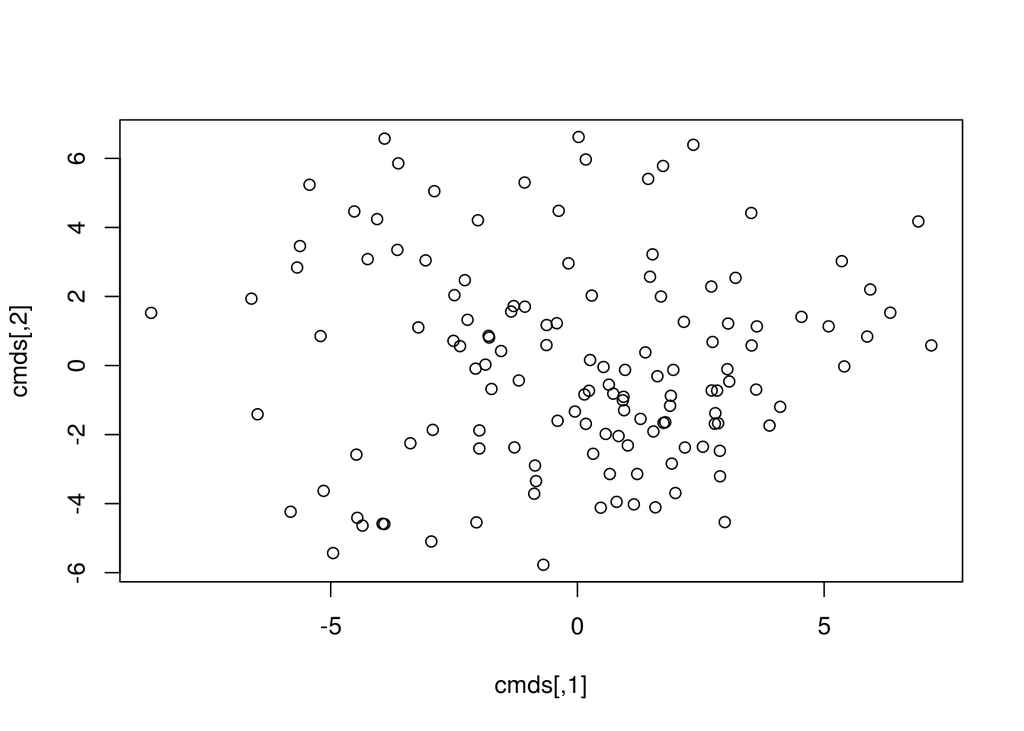

```r
plot(cmds)
```

## Calidad de los datos

```r
## suma de eigenvalores entre la traza de B:
M<-sum(diag(G2))/sum(diag(B))
M
```

```
## [1] 1
```

Agregamos los partidos al dataframe que se genara a partir de Xk

```r
## creamos un dataframe de las 2 dimensiones
mds<-as.data.frame(cmds)
mds[1:3,]
```

```
##                                        V1        V2
## ACOSTA ISLAS ANABEL             -2.900018  5.050212
## ALBARRAN MENDOZA ESTEBAN         5.091143  1.135077
## ALBORES GLEASON ROBERTO ARMANDO -2.960547 -5.097369
```

```r
##ordenamos los nombres de los senadores por nombre y apellidos
firstname = sapply(strsplit(rownames(mds), ' '), function(x) {if (is.na(x[4])) {return (x[3])} else if(is.na(x[5])){return (paste(x[3],x[4]))}
  else if(is.na(x[6])){return(paste(x[3],x[4],x[5]))} else if(is.na(x[7])){return(paste(x[3],x[4],x[5],x[6]))}})

lastname1 = sapply(strsplit(rownames(mds), ' '), function(x) x[1])
lastname2 = sapply(strsplit(rownames(mds), ' '), function(x) x[2])
mds$SENADOR<-paste(firstname,lastname1,lastname2,sep=" ")

##generamos el catálogo de senadores y partidos
prt<-unique(part[,2:3])

##pegamos el partido al dataframe mds
fin<-merge(x = mds, y = prt, by = "SENADOR", all.x = TRUE)
fin[11,]$PARTIDO<-'PRI'
fin[15,]$PARTIDO<-'PAN'
fin[20,]$PARTIDO<-'PAN'
fin[57,]$PARTIDO<-'PRI'
fin[69,]$PARTIDO<-'PRI'
fin[104,]$PARTIDO<-'PAN'
fin[109,]$PARTIDO<-'PRD'
fin[120,]$PARTIDO<-'PT'
fin[131,]$PARTIDO<-'PRI'
```

## GRAFICO

Graficamos a los senadores por distinguidos por su partido en las 2 primeras dimensiones:

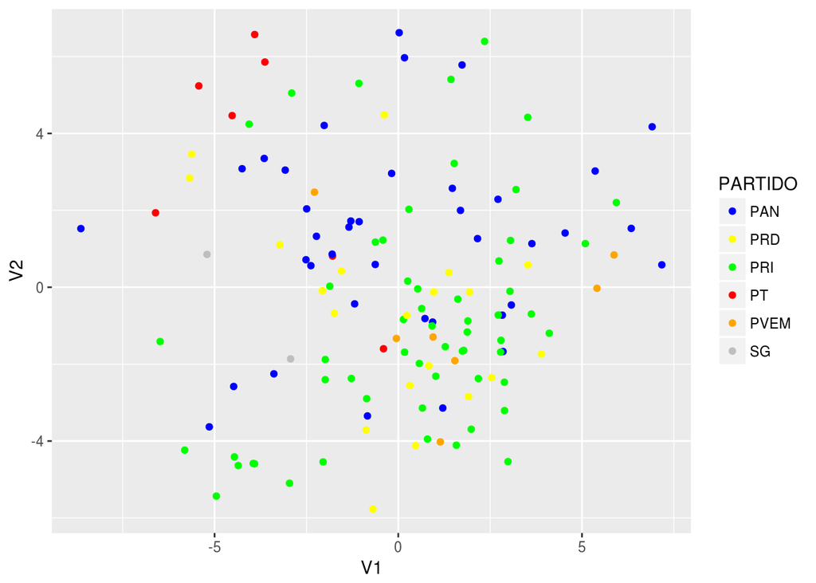

```r
library('ggplot2')
pl<-ggplot(fin, aes(x=V1, y=V2,text = paste(SENADOR))) + geom_point(aes(color=PARTIDO)) +
  scale_color_manual(values=c("blue", "yellow", "green","red","orange","gray","black"))

print(pl)
```